# Feature Selection Analysis using Stepwise Regression models

# Data Preparation

### Importing Libraries

```python
import numpy as np
import pandas as pd
import matplotlib.pyplot as plt
```

### read CSV File

```python
data = pd.read_csv('50_Startups.csv')
```

### preview of the contents of the dataframe

```python
data.head()
```

|  | R&D Spend | Administration | Marketing Spend | State | Profit |
| --- | --- | --- | --- | --- | --- |
| 0 | 165349.20 | 136897.80 | 471784.10 | New York | 192261.83 |
| 1 | 162597.70 | 151377.59 | 443898.53 | California | 191792.06 |
| 2 | 153441.51 | 101145.55 | 407934.54 | Florida | 191050.39 |
| 3 | 144372.41 | 118671.85 | 383199.62 | New York | 182901.99 |
| 4 | 142107.34 | 91391.77 | 366168.42 | Florida | 166187.94 |

### fm (feature matrix) -- collection of independent variables -- R&D, Admin, Marketing Spend and State

### v (variable) -- dependent variable -- Profit

```python
fm = data.iloc[:,:-1].values
v = data.iloc[:,-1].values
```

### encode the 'State' attribute into numbers

```python
from sklearn.compose import ColumnTransformer
from sklearn.preprocessing import OneHotEncoder
ct = ColumnTransformer(transformers=[('encoder',OneHotEncoder(),[3])],remainder='passthrough')
fm = ct.fit_transform(fm)
```

### split of feature matrix into training and test set

### //based on predefined test_size and random_state for all models//

### training set -- for the machine to learn from

### test set -- to test machine's profit prediction

```python
test_size = 0.25
random_state = 10
```

```python
from sklearn.model_selection import train_test_split
fm_train,fm_test,v_train,v_test = train_test_split(fm,v,test_size=test_size,random_state=random_state)
```

# General Trends

### profit versus expenditure on R&D (sampled from training set)

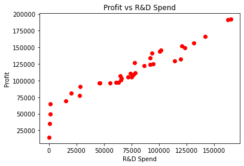

```python
plt.scatter(fm_train[:,3],v_train,color='red')
plt.title('Profit vs R&D Spend')
plt.xlabel('R&D Spend')
plt.ylabel('Profit')
plt.show()
```

### profit versus expenditure on administration (sampled from training set)

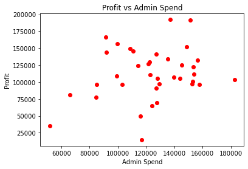

```python
plt.scatter(fm_train[:,4],v_train,color='red')
plt.title('Profit vs Admin Spend')
plt.xlabel('Admin Spend')
plt.ylabel('Profit')
plt.show()
```

### profit versus expenditure on marketing (sampled from training set)

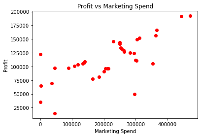

```python
plt.scatter(fm_train[:,5],v_train,color='red')
plt.title('Profit vs Marketing Spend')
plt.xlabel('Marketing Spend')
plt.ylabel('Profit')
plt.show()
```

# Analysis 1:

## >A Strong linear relationship exists between a Startup's Profits and their R&D Spend.

## > Profit dependence on Admin Spend appears to be random.

## >Profits portray a positive trend with increasing Marketing Spend.

# Step 1: allow scikit-learn to extract stastically significant features and predict profits

### invocation of the linear regressor and fitting to the training set

```python
from sklearn.linear_model import LinearRegression
reg = LinearRegression()
reg.fit(fm_train,v_train)
```

```
LinearRegression()
```

### machine's prediction assigned to 'v_pred'

```python
v_pred = reg.predict(fm_test)
```

# Step 2: manually implement Backward Selection

### remove first column of dataframe (avoid dummy variable trap)

```python
fm = fm[:,1:]
```

### append column vector of 1's at the beginning of matrix for interpretation of constant term in Mutiple LR

```python
import statsmodels.api as sm
fm = np.append(arr = np.ones((50,1)).astype(int), values = fm, axis = 1)
```

## Ordinary Least Square Regression Results display p-values stagewise

### Initial Matrix preview

```python
print(fm[0:3,[0,1,2,3,4,5]])
```

```
[[1 0.0 1.0 165349.2 136897.8 471784.1]
 [1 0.0 0.0 162597.7 151377.59 443898.53]
 [1 1.0 0.0 153441.51 101145.55 407934.54]]
```

### Initially, all the features are passed

```python
fm_opt = fm[:, [0, 1, 2, 3, 4, 5]]
fm_opt = fm_opt.astype(np.float64)
regressor_OLS = sm.OLS(endog = v, exog = fm_opt).fit()
regressor_OLS.summary()
```

OLS Regression Results

| Dep. Variable: | y | R-squared: | 0.951 |
| --- | --- | --- | --- |
| Model: | OLS | Adj. R-squared: | 0.945 |
| Method: | Least Squares | F-statistic: | 169.9 |
| Date: | Wed, 27 Apr 2022 | Prob (F-statistic): | 1.34e-27 |
| Time: | 18:30:28 | Log-Likelihood: | -525.38 |
| No. Observations: | 50 | AIC: | 1063. |
| Df Residuals: | 44 | BIC: | 1074. |
| Df Model: | 5 |  |  |
| Covariance Type: | nonrobust |  |  |

|  | coef | std err | t | P>\|t\| | [0.025 | 0.975] |
| --- | --- | --- | --- | --- | --- | --- |
| const | 5.013e+04 | 6884.820 | 7.281 | 0.000 | 3.62e+04 | 6.4e+04 |
| x1 | 198.7888 | 3371.007 | 0.059 | 0.953 | -6595.030 | 6992.607 |
| x2 | -41.8870 | 3256.039 | -0.013 | 0.990 | -6604.003 | 6520.229 |
| x3 | 0.8060 | 0.046 | 17.369 | 0.000 | 0.712 | 0.900 |
| x4 | -0.0270 | 0.052 | -0.517 | 0.608 | -0.132 | 0.078 |
| x5 | 0.0270 | 0.017 | 1.574 | 0.123 | -0.008 | 0.062 |

| Omnibus: | 14.782 | Durbin-Watson: | 1.283 |
| --- | --- | --- | --- |
| Prob(Omnibus): | 0.001 | Jarque-Bera (JB): | 21.266 |
| Skew: | -0.948 | Prob(JB): | 2.41e-05 |
| Kurtosis: | 5.572 | Cond. No. | 1.45e+06 |

Notes:  
[1] Standard Errors assume that the covariance matrix of the errors is correctly specified.  
[2] The condition number is large, 1.45e+06. This might indicate that there are  
strong multicollinearity or other numerical problems.

### feature x2 (dummy variable) is removed, as it has highest relative p-value, and model is re-fit

### Matrix Preview after feature x2 is removed

```python
print(fm[0:3,[0,1,3,4,5]])
```

```
[[1 0.0 165349.2 136897.8 471784.1]
 [1 0.0 162597.7 151377.59 443898.53]
 [1 1.0 153441.51 101145.55 407934.54]]
```

```python
fm_opt = fm[:, [0, 1, 3, 4, 5]]
fm_opt = fm_opt.astype(np.float64)
regressor_OLS = sm.OLS(endog = v, exog = fm_opt).fit()
regressor_OLS.summary()
```

OLS Regression Results

| Dep. Variable: | y | R-squared: | 0.951 |
| --- | --- | --- | --- |
| Model: | OLS | Adj. R-squared: | 0.946 |
| Method: | Least Squares | F-statistic: | 217.2 |
| Date: | Wed, 27 Apr 2022 | Prob (F-statistic): | 8.49e-29 |
| Time: | 18:30:28 | Log-Likelihood: | -525.38 |
| No. Observations: | 50 | AIC: | 1061. |
| Df Residuals: | 45 | BIC: | 1070. |
| Df Model: | 4 |  |  |
| Covariance Type: | nonrobust |  |  |

|  | coef | std err | t | P>\|t\| | [0.025 | 0.975] |
| --- | --- | --- | --- | --- | --- | --- |
| const | 5.011e+04 | 6647.870 | 7.537 | 0.000 | 3.67e+04 | 6.35e+04 |
| x1 | 220.1585 | 2900.536 | 0.076 | 0.940 | -5621.821 | 6062.138 |
| x2 | 0.8060 | 0.046 | 17.606 | 0.000 | 0.714 | 0.898 |
| x3 | -0.0270 | 0.052 | -0.523 | 0.604 | -0.131 | 0.077 |
| x4 | 0.0270 | 0.017 | 1.592 | 0.118 | -0.007 | 0.061 |

| Omnibus: | 14.758 | Durbin-Watson: | 1.282 |
| --- | --- | --- | --- |
| Prob(Omnibus): | 0.001 | Jarque-Bera (JB): | 21.172 |
| Skew: | -0.948 | Prob(JB): | 2.53e-05 |
| Kurtosis: | 5.563 | Cond. No. | 1.40e+06 |

Notes:  
[1] Standard Errors assume that the covariance matrix of the errors is correctly specified.  
[2] The condition number is large, 1.4e+06. This might indicate that there are  
strong multicollinearity or other numerical problems.

### feature x1 (dummy variable) is removed, as it has highest relative p-value, and model is re-fit

# Analysis 2:

## >Both dummy variables passed turn out to be statistically insignificant in Profit prediction.

## >This indicates that the Statwise distribution of Profits is likely to be similar

## >A Boxplot visual on the same illustrates this

```python
ny_profits = [v[i] for i in range(len(fm[:,2])) if fm[i,2] == 1.0]
cali_profits = [v[i] for i in range(len(fm[:,0])) if fm[i,0] == 1.0]
florida_profits = [v[i] for i in range(len(fm[:,1])) if fm[i,1] == 1.0]
```

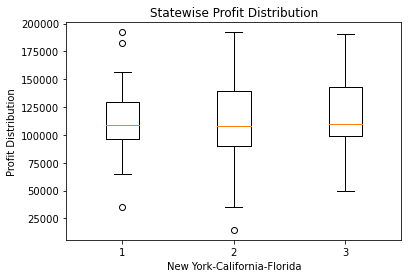

```python
plt.boxplot([ny_profits,cali_profits,florida_profits])
plt.title('Statewise Profit Distribution')
plt.xlabel('New York-California-Florida')
plt.ylabel('Profit Distribution')
plt.show()
```

```python
len(ny_profits),len(cali_profits),len(florida_profits)
```

```
(17, 50, 16)
```

## Backward Elimination continued

### Matrix Preview after feature x1 is removed

```python
print(fm[0:3,[0,3,4,5]])
```

```
[[1 165349.2 136897.8 471784.1]
 [1 162597.7 151377.59 443898.53]
 [1 153441.51 101145.55 407934.54]]
```

```python
fm_opt = fm[:, [0, 3, 4, 5]]
fm_opt = fm_opt.astype(np.float64)
regressor_OLS = sm.OLS(endog = v, exog = fm_opt).fit()
regressor_OLS.summary()
```

OLS Regression Results

| Dep. Variable: | y | R-squared: | 0.951 |
| --- | --- | --- | --- |
| Model: | OLS | Adj. R-squared: | 0.948 |
| Method: | Least Squares | F-statistic: | 296.0 |
| Date: | Wed, 27 Apr 2022 | Prob (F-statistic): | 4.53e-30 |
| Time: | 18:30:29 | Log-Likelihood: | -525.39 |
| No. Observations: | 50 | AIC: | 1059. |
| Df Residuals: | 46 | BIC: | 1066. |
| Df Model: | 3 |  |  |
| Covariance Type: | nonrobust |  |  |

|  | coef | std err | t | P>\|t\| | [0.025 | 0.975] |
| --- | --- | --- | --- | --- | --- | --- |
| const | 5.012e+04 | 6572.353 | 7.626 | 0.000 | 3.69e+04 | 6.34e+04 |
| x1 | 0.8057 | 0.045 | 17.846 | 0.000 | 0.715 | 0.897 |
| x2 | -0.0268 | 0.051 | -0.526 | 0.602 | -0.130 | 0.076 |
| x3 | 0.0272 | 0.016 | 1.655 | 0.105 | -0.006 | 0.060 |

| Omnibus: | 14.838 | Durbin-Watson: | 1.282 |
| --- | --- | --- | --- |
| Prob(Omnibus): | 0.001 | Jarque-Bera (JB): | 21.442 |
| Skew: | -0.949 | Prob(JB): | 2.21e-05 |
| Kurtosis: | 5.586 | Cond. No. | 1.40e+06 |

Notes:  
[1] Standard Errors assume that the covariance matrix of the errors is correctly specified.  
[2] The condition number is large, 1.4e+06. This might indicate that there are  
strong multicollinearity or other numerical problems.

### feature x2 (Admin Spend) is removed, as it has highest relative p-value, and model is re-fit

### Matrix Preview after feature x2 is removed

```python
print(fm[0:3,[0,3,5]])
```

```
[[1 165349.2 471784.1]
 [1 162597.7 443898.53]
 [1 153441.51 407934.54]]
```

```python
fm_opt = fm[:, [0, 3, 5]]
fm_opt = fm_opt.astype(np.float64)
regressor_OLS = sm.OLS(endog = v, exog = fm_opt).fit()
regressor_OLS.summary()
```

OLS Regression Results

| Dep. Variable: | y | R-squared: | 0.950 |
| --- | --- | --- | --- |
| Model: | OLS | Adj. R-squared: | 0.948 |
| Method: | Least Squares | F-statistic: | 450.8 |
| Date: | Wed, 27 Apr 2022 | Prob (F-statistic): | 2.16e-31 |
| Time: | 18:30:29 | Log-Likelihood: | -525.54 |
| No. Observations: | 50 | AIC: | 1057. |
| Df Residuals: | 47 | BIC: | 1063. |
| Df Model: | 2 |  |  |
| Covariance Type: | nonrobust |  |  |

|  | coef | std err | t | P>\|t\| | [0.025 | 0.975] |
| --- | --- | --- | --- | --- | --- | --- |
| const | 4.698e+04 | 2689.933 | 17.464 | 0.000 | 4.16e+04 | 5.24e+04 |
| x1 | 0.7966 | 0.041 | 19.266 | 0.000 | 0.713 | 0.880 |
| x2 | 0.0299 | 0.016 | 1.927 | 0.060 | -0.001 | 0.061 |

| Omnibus: | 14.677 | Durbin-Watson: | 1.257 |
| --- | --- | --- | --- |
| Prob(Omnibus): | 0.001 | Jarque-Bera (JB): | 21.161 |
| Skew: | -0.939 | Prob(JB): | 2.54e-05 |
| Kurtosis: | 5.575 | Cond. No. | 5.32e+05 |

Notes:  
[1] Standard Errors assume that the covariance matrix of the errors is correctly specified.  
[2] The condition number is large, 5.32e+05. This might indicate that there are  
strong multicollinearity or other numerical problems.

### feature x2 (Marketing Spend) is removed, as it has highest relative p-value, and model is re-fit

### Matrix Preview after feature x2 is removed

```python
print(fm[0:3,[0,3]])
```

```
[[1 165349.2]
 [1 162597.7]
 [1 153441.51]]
```

```python
fm_opt = fm[:, [0, 3]]
fm_opt = fm_opt.astype(np.float64)
regressor_OLS = sm.OLS(endog = v, exog = fm_opt).fit()
regressor_OLS.summary()
```

OLS Regression Results

| Dep. Variable: | y | R-squared: | 0.947 |
| --- | --- | --- | --- |
| Model: | OLS | Adj. R-squared: | 0.945 |
| Method: | Least Squares | F-statistic: | 849.8 |
| Date: | Wed, 27 Apr 2022 | Prob (F-statistic): | 3.50e-32 |
| Time: | 18:30:29 | Log-Likelihood: | -527.44 |
| No. Observations: | 50 | AIC: | 1059. |
| Df Residuals: | 48 | BIC: | 1063. |
| Df Model: | 1 |  |  |
| Covariance Type: | nonrobust |  |  |

|  | coef | std err | t | P>\|t\| | [0.025 | 0.975] |
| --- | --- | --- | --- | --- | --- | --- |
| const | 4.903e+04 | 2537.897 | 19.320 | 0.000 | 4.39e+04 | 5.41e+04 |
| x1 | 0.8543 | 0.029 | 29.151 | 0.000 | 0.795 | 0.913 |

| Omnibus: | 13.727 | Durbin-Watson: | 1.116 |
| --- | --- | --- | --- |
| Prob(Omnibus): | 0.001 | Jarque-Bera (JB): | 18.536 |
| Skew: | -0.911 | Prob(JB): | 9.44e-05 |
| Kurtosis: | 5.361 | Cond. No. | 1.65e+05 |

Notes:  
[1] Standard Errors assume that the covariance matrix of the errors is correctly specified.  
[2] The condition number is large, 1.65e+05. This might indicate that there are  
strong multicollinearity or other numerical problems.

## Backward Elimination is concluded, as all p-values of remaining features are below 0.05

### Final Matrix of Features (preview) contain a constant term and R&D Spend

```python
print(fm[0:3,[0,3]])
```

```
[[1 165349.2]
 [1 162597.7]
 [1 153441.51]]
```

# Analysis 3:

## > Since only the R&D Spend feature remains, (intercept term held aside), the 'General Trend Graphs' intuition appears negotiable.

## > This leads to the fact that Profit varying only as a function of R&D Spend (Simple Linear Regression) is a good approximation to the model (later confirmed by r2_scores).

## Implement model using backward elimination optimised feature matrix

```python
fm_b_elim_train,fm_b_elim_test,v_b_elim_train,v_b_elim_test = train_test_split(fm[:,3].reshape(len(fm[:,3]),1),
                                                                               v,test_size=test_size,random_state=random_state)
```

```python
b_elim_reg = LinearRegression()
b_elim_reg.fit(fm_b_elim_train,v_b_elim_train)
```

```
LinearRegression()
```

```python
v_b_elim_pred = b_elim_reg.predict(fm_b_elim_test)
```

# Step 3: Implement model using Forward Selection

### reassign feature matrix to original

```python
fm = data.iloc[:,:-1].values
ct = ColumnTransformer(transformers=[('encoder',OneHotEncoder(),[3])],remainder='passthrough')
fm = ct.fit_transform(fm)
```

## Identify two most statistically significant features using Forward Selection and verify results from Backward Elimination

```python
from sklearn.linear_model import LinearRegression
from mlxtend.feature_selection import SequentialFeatureSelector as sfs
regressor = LinearRegression()
sfs1 = sfs(regressor, k_features=2, forward=True, verbose=2, scoring= 'neg_mean_squared_error')
sfs1 = sfs1.fit(fm,v)
```

```
[Parallel(n_jobs=1)]: Using backend SequentialBackend with 1 concurrent workers.
[Parallel(n_jobs=1)]: Done   1 out of   1 | elapsed:    0.0s remaining:    0.0s
[Parallel(n_jobs=1)]: Done   6 out of   6 | elapsed:    0.0s finished

[2022-04-27 18:30:29] Features: 1/2 -- score: -99665424.82352272[Parallel(n_jobs=1)]: Using backend SequentialBackend with 1 concurrent workers.
[Parallel(n_jobs=1)]: Done   1 out of   1 | elapsed:    0.0s remaining:    0.0s
[Parallel(n_jobs=1)]: Done   5 out of   5 | elapsed:    0.0s finished

[2022-04-27 18:30:29] Features: 2/2 -- score: -94580206.64311817
```

# Analysis 4:

## feat_vals -- values of those features identified as statistically significant by forward selection

```python
data.head()
```

|  | R&D Spend | Administration | Marketing Spend | State | Profit |
| --- | --- | --- | --- | --- | --- |
| 0 | 165349.20 | 136897.80 | 471784.10 | New York | 192261.83 |
| 1 | 162597.70 | 151377.59 | 443898.53 | California | 191792.06 |
| 2 | 153441.51 | 101145.55 | 407934.54 | Florida | 191050.39 |
| 3 | 144372.41 | 118671.85 | 383199.62 | New York | 182901.99 |
| 4 | 142107.34 | 91391.77 | 366168.42 | Florida | 166187.94 |

```python
feat_vals = [int(i) for i in list(sfs1.k_feature_names_)]
print(fm[:,feat_vals][0:3,:])
```

```
[[165349.2 471784.1]
 [162597.7 443898.53]
 [153441.51 407934.54]]
```

## >By checking, it is confirmed that the forward selection algorithm (when forced to extract two of the most statistically significant features) selects R&D Spend and Marketing Spend.

## >This result is in agreement to the penultimate observation of Backward Selection.

## Now, implement the model as per features given by Forward Selection

```python
fm_f_sel_train,fm_f_sel_test,v_f_sel_train,v_f_sel_test = train_test_split(fm[:,feat_vals],v,test_size=test_size,random_state=random_state)
```

```python
from sklearn.linear_model import LinearRegression
f_sel_reg = LinearRegression()
f_sel_reg.fit(fm_f_sel_train,v_f_sel_train)
```

```
LinearRegression()
```

```python
v_f_sel_pred = f_sel_reg.predict(fm_f_sel_test)
```

# Data Visualization

## -- Red point indicates machine's predicted profit

## -- Blue point indicates actual profit

### visual on actual versus predicted profit (evaluated by sklearn)

[figure not shown]

```python
index = range(1,len(v_test)+1)
plt.scatter(index,v_test,color='blue')
plt.scatter(index,v_pred,color='red')
plt.title('Actual/Predicted Profit for 10 Startups')
plt.xlabel('Company Index')
plt.ylabel('Actual/Predicted Profit')
plt.show()
```

### visual on actual versus predicted profit (evaluated by manual backward elimination)

[figure not shown]

```python
index = range(1,len(v_b_elim_test)+1)
plt.scatter(index,v_b_elim_test,color='blue')
plt.scatter(index,v_b_elim_pred,color='red')
plt.title('Actual/Predicted Profit for 10 Startups')
plt.xlabel('Company Index')
plt.ylabel('Actual/Predicted Profit')
plt.show()
```

### visual on actual versus predicted profit (evaluated by manual forward selection)

[figure not shown]

```python
index = range(1,len(v_f_sel_test)+1)
plt.scatter(index,v_f_sel_test,color='blue')
plt.scatter(index,v_f_sel_pred,color='red')
plt.title('Actual/Predicted Profit for 10 Startups')
plt.xlabel('Company Index')
plt.ylabel('Actual/Predicted Profit')
plt.show()
```

### quantitative data on the actual profit versus the predicted profit (evaluated by sklearn)

```python
np.set_printoptions(precision=0)
print(np.concatenate((v_test.reshape(len(v_test),1),v_pred.reshape(len(v_pred),1)),1))
```

```
[[ 89949.  88857.]
 [108734. 109300.]
 [ 65200.  66680.]
 [ 71498.  71093.]
 [ 42560.  48589.]
 [118474. 116162.]
 [182902. 171322.]
 [ 99938.  99971.]
 [155753. 159258.]
 [156123. 158377.]
 [ 81006.  83684.]
 [191050. 179967.]
 [ 78240.  75512.]]
```

### quantitative data on the actual profit versus the predicted profit (evaluated by manual backward elimination)

```python
np.set_printoptions(precision=0)
print(np.concatenate((v_b_elim_test.reshape(len(v_b_elim_test),1),v_b_elim_pred.reshape(len(v_b_elim_pred),1)),1))
```

```
[[ 89949.  86814.]
 [108734. 106482.]
 [ 65200.  68462.]
 [ 71498.  69688.]
 [ 42560.  49870.]
 [118474. 113794.]
 [182902. 170897.]
 [ 99938. 101840.]
 [155753. 159099.]
 [156123. 162718.]
 [ 81006.  82194.]
 [191050. 178500.]
 [ 78240.  73975.]]
```

### quantitative data on the actual profit versus the predicted profit (evaluated by manual forward selection)

```python
np.set_printoptions(precision=0)
print(np.concatenate((v_f_sel_test.reshape(len(v_f_sel_test),1),v_f_sel_pred.reshape(len(v_f_sel_pred),1)),1))
```

```
[[ 89949.  87854.]
 [108734. 108995.]
 [ 65200.  66502.]
 [ 71498.  70515.]
 [ 42560.  48272.]
 [118474. 115752.]
 [182902. 171685.]
 [ 99938.  99515.]
 [155753. 159130.]
 [156123. 157868.]
 [ 81006.  82966.]
 [191050. 179453.]
 [ 78240.  75154.]]
```

## Comparison of r2_scores (an accuracy measure of regression models graded 0 to 1)

### scikit learn prediction

```python
from sklearn.metrics import r2_score
print('{score:1.6f}'.format(score=r2_score(v_test,v_pred)))
```

```
0.987405
```

### backward elimination's prediction (only R&D Spend accounted)

```python
print('{score:1.6f}'.format(score=r2_score(v_b_elim_test,v_b_elim_pred)))
```

```
0.981786
```

### feature selection's prediction (both R&D spend and Marketing Spend accounted)

```python
print('{score:1.6f}'.format(score=r2_score(v_f_sel_test,v_f_sel_pred)))
```

```
0.987368
```

# Analysis 5:

```python
obs = [[0.2,1,0.964962,0.96104,0.964644],
[0.2,2,0.978326,0.978148,0.981418],
[0.2,3,0.944206,0.95655,0.961288],
[0.2,4,0.956036,0.961321,0.967485],
[0.2,5,0.966976,0.972811,0.96836],
[0.25,6,0.917621,0.914028,0.921129],
[0.25,7,0.925066,0.936618,0.939721],
[0.25,8,0.899269,0.902233,0.909121],
[0.25,9,0.888097,0.896608,0.901835],
[0.25,10,0.987405,0.981786,0.987368]]


r2_score_metrics = pd.DataFrame(data = obs, columns= ['TEST SIZE','RANDOM_STATE','SCIKIT ACCURACY','R&D ONLY','R&D AND MARKETING'])
print('\n',r2_score_metrics,'\n')
print('\nAverage: 0.9427964,0.9461143,0.9502369')
```

```
    TEST SIZE  RANDOM_STATE  SCIKIT ACCURACY  R&D ONLY  R&D AND MARKETING
0       0.20             1         0.964962  0.961040           0.964644
1       0.20             2         0.978326  0.978148           0.981418
2       0.20             3         0.944206  0.956550           0.961288
3       0.20             4         0.956036  0.961321           0.967485
4       0.20             5         0.966976  0.972811           0.968360
5       0.25             6         0.917621  0.914028           0.921129
6       0.25             7         0.925066  0.936618           0.939721
7       0.25             8         0.899269  0.902233           0.909121
8       0.25             9         0.888097  0.896608           0.901835
9       0.25            10         0.987405  0.981786           0.987368


Average: 0.9427964,0.9461143,0.9502369
```